# Phenotypic Analysis

## Plot the frequency of different functions amongst annotated ASVs

When examining the most frequent functions in our samples we see an interesting trend where samples from the UK tend to have more annotated ASVs than samples from the West Coast.

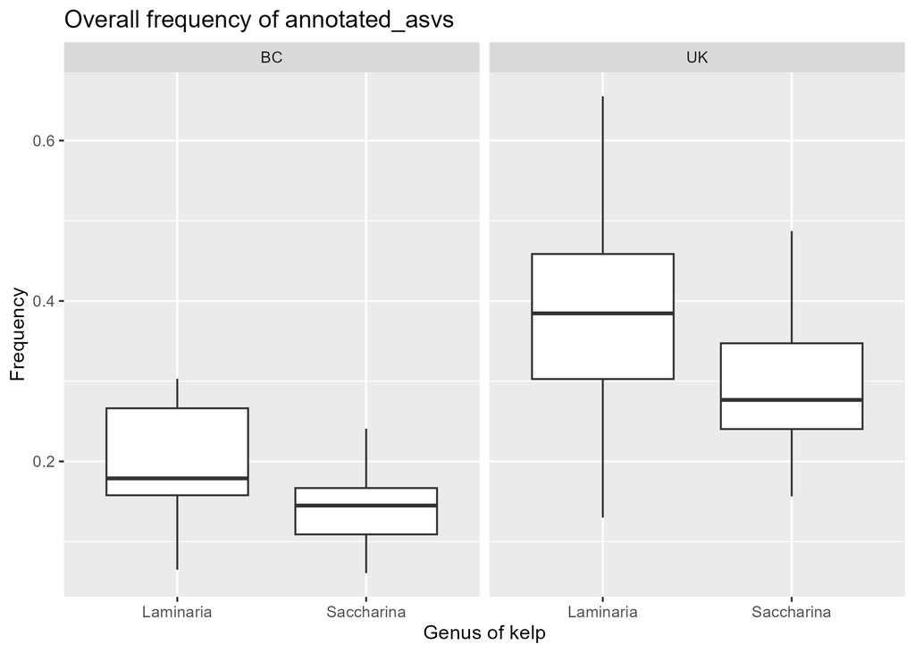

Figure 1

To reduce this bias this we will calculate normalize relative frequency of the most common functions among the annotated ASVs by the number of annotated ASVs in a sample. Assuming that these are a representative sample of the overall functional profile of the population, this should help reduce this bias.

### Region

```r
func_table.long$relative_annotated_abundance = func_table.long$function_abundance/func_table.long$annotated_asvs2

for (f in top.df$eco_function){
  funcdata = subset(func_table.long, eco_function == f)
  funcy_plot = ggplot(funcdata, aes(x=as.character(genus), y = as.numeric(relative_annotated_abundance)))+
    geom_boxplot(outliers=FALSE)+
    facet_grid(.~Region, scales="free", space="free")+
    ggtitle(paste("Frequency of", f, "amongst annotated reads", sep = " "))+
    labs(y="Frequency", x="Genus of kelp")
  ggsave(paste0(f,"_by_region",  ".png"), plot = funcy_plot, path = "figures/annotated")
}
```

### Location

```r
for (f in top.df$eco_function){
  funcdata_bc = subset(func_table.long, eco_function == f & Region == "BC")
  funcdata_uk = subset(func_table.long, eco_function == f & Region == "UK")
  funcy_plot_bc = ggplot(funcdata_bc, aes(x=as.character(Location), y = as.numeric(relative_annotated_abundance)))+
    geom_point()+
    facet_grid(.~genus, scales="free", space="free")+
    ggtitle(paste("Frequency of", f, "amongst annotated reads", sep = " "))+
    labs(y="Frequency", x="Location")
  ggsave(paste0(f,"_by_location_bc",  ".png"), plot = funcy_plot_bc, path = "figures/overall/data_by_location")
  funcy_plot_uk = ggplot(funcdata_uk, aes(x=as.character(Location), y = as.numeric(relative_annotated_abundance)))+
    geom_point()+
    facet_grid(.~genus, scales="free", space="free")+
    ggtitle(paste("Frequency of", f, "amongst annotated reads", sep = " "))+
    labs(y="Frequency", x="Location")
  ggsave(paste0(f,"_by_location_uk",  ".png"), plot = funcy_plot_uk, path = "figures/annotated/data_by_location")
}
```

## Removing redundant functions

In our analysis it is now necessary to note that FAPROTAX classifies certain functions as nested within each other. For instance, all OTUs that were assigned aerobic chemoheterotrophy were also assigned chemoheterotrophy. In our results we can see this as several taxa have very similar frequencies to the taxa they are nested within.

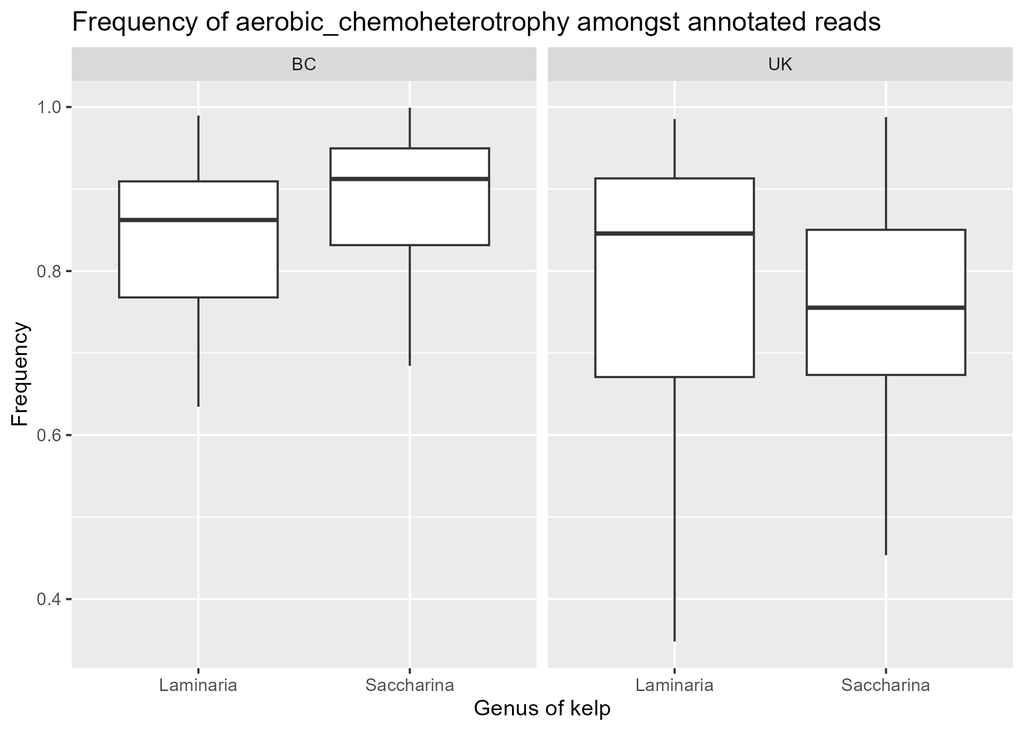

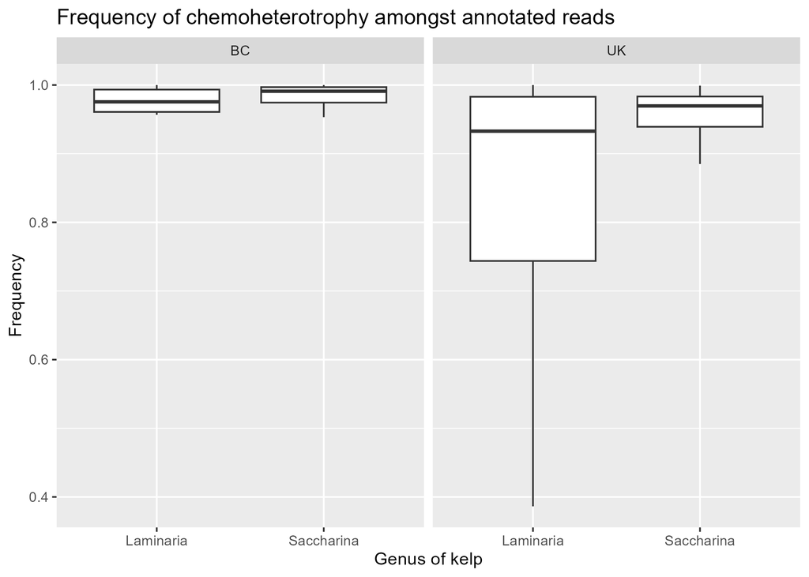

Other examples of such nested phenotypes are:

- dark sulfur oxidation is nested in dark oxidation of sulfur compounds
- oxygenic photoautotrophy and photoautotrophy are nested in phototrophy

For further analysis then we will focus only on these nested functions as they provide the most specific information about the functional profile of these microbial communities. However, there are also functions which seem similar, both in their frequencies as well as their purposes, but are not nested within each another function. For instance:

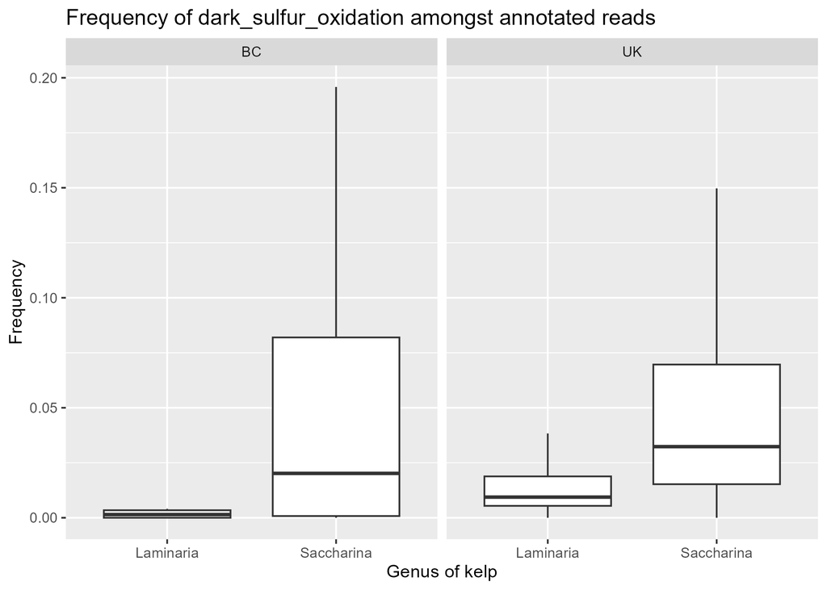

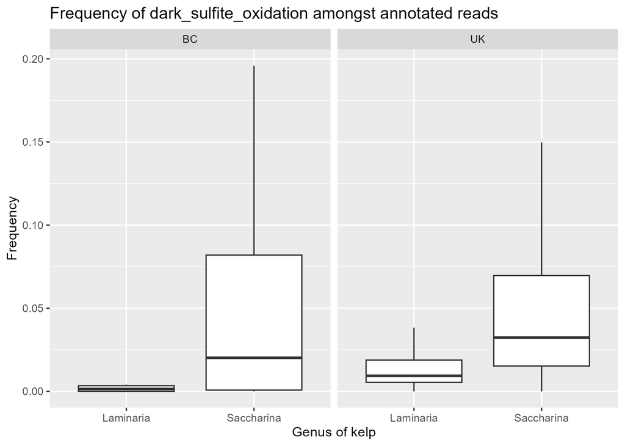

as well as

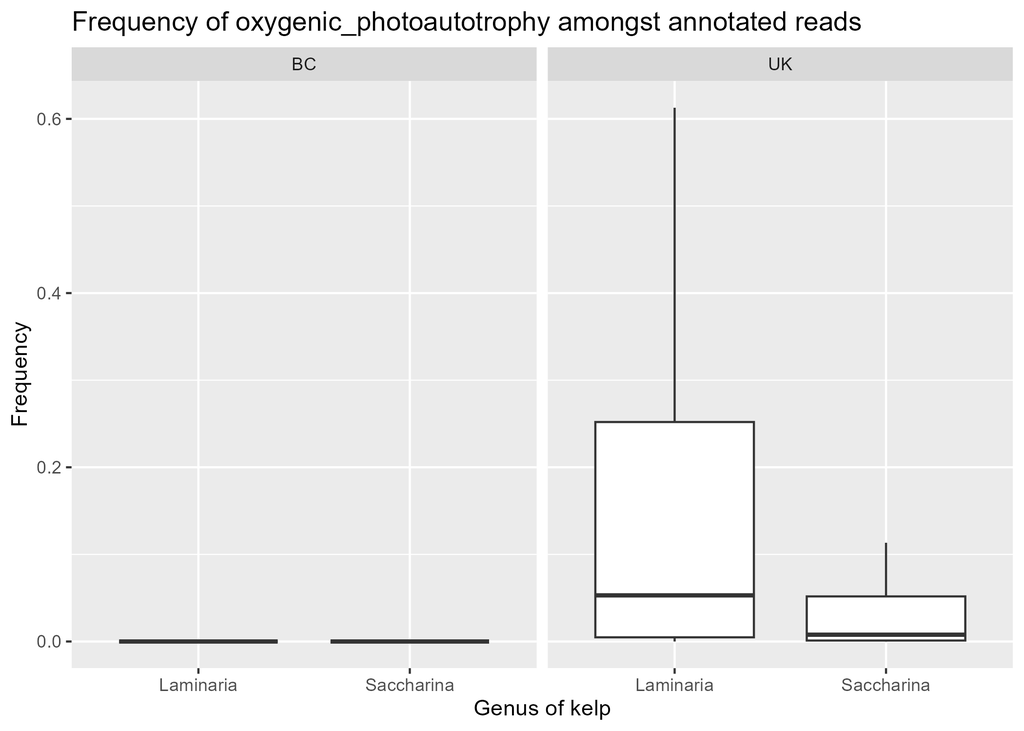

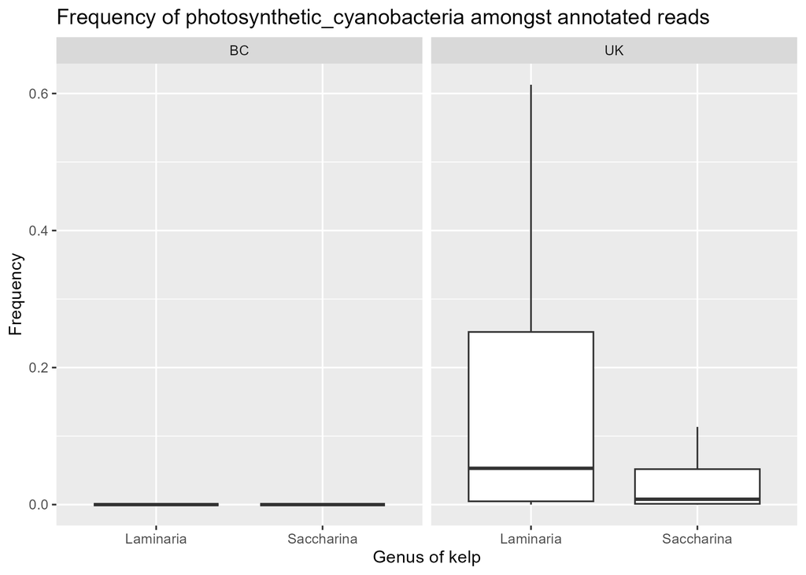

We can now examine the overlaps tables for why this might be the case

```r
overlaps = read.table("kelpme_overlaps.txt", sep = "\t", row.names = 1, header = TRUE)

## first look at the overlap between dark sulfite and dark sulfur oxidation
print(overlaps["dark_sulfite_oxidation","dark_sulfur_oxidation"])
```

```
## [1] 1
```

```r
## next look at the overlap between photosynthetic cyanobacteria and oxygenic photoautotrophy
print(overlaps["photosynthetic_cyanobacteria","oxygenic_photoautotrophy"])
```

```
## [1] 1
```

Then we can see that there is a total overlap between species assigned dark sulfite oxidation and dark sulfur oxidation, as well as between those assigned photosynthetic cyanobacteria and oxygenic photoautotrophy. We will then exclude dark sulfite oxidation and photosynthetic cyanobacteria from further analysis as they are redundant.

## A preliminary functional profile

Comparing the different functions present in our samples there is evidence for the presence of aerobic chemoheterotrophy across sites and samples. There is also some evidence for the presence of dark sulfur oxidation, oxygenic photoautotrophy, fermentation, and predation/parasitism (predatory_or_exoparasitic) at low levels in some cases. We can check this by running a single sample t-test, comparing the frequency of each of these traits to 0. To do this test we will group our data by the kelp and region where the sample was collected.

```r
## first create the comparison groups
func_table.long$comparison_groups = paste0(func_table.long$genus, ";", func_table.long$Region)
## initialize the data frame we will store our significance tests in
sig_vals = data.frame(matrix(ncol=6,nrow=0))
names(sig_vals) = c("Kelp; Region", "eco_function", "p", "p.signif", "p.adj", "p.adj.signif")
## create a list of the functions we are interested in
main.funcs = list("aerobic_chemoheterotrophy", "dark_sulfur_oxidation", "oxygenic_photoautotrophy", "fermentation", "predatory_or_exoparasitic")
## check if the mean frequency of these functions in each group is significantly different from 0
for(f in main.funcs){
  funcdata = subset(func_table.long, eco_function == f)
  sig.test = funcdata %>%
    group_by(comparison_groups) %>%
    t_test(relative_abundance ~ 0) %>%
    add_significance() %>%
    adjust_pvalue() %>%
    add_significance()
  sig.test = subset(sig.test, select = c("comparison_groups", "p", "p.signif", "p.adj", "p.adj.signif"))
  sig.test$eco_function = f
  sig_vals = rbind(sig_vals, sig.test)
}
print(sig_vals)
```

```
## # A tibble: 20 × 6
##    comparison_groups        p p.signif    p.adj p.adj.signif eco_function
##    <chr>                <dbl> <chr>       <dbl> <chr>        <chr>
##  1 Laminaria;BC      3.68e- 3 **       3.68e- 3 **           aerobic_chemoheter…
##  2 Laminaria;UK      6.13e-29 ****     1.84e-28 ****         aerobic_chemoheter…
##  3 Saccharina;BC     3.36e-10 ****     6.72e-10 ****         aerobic_chemoheter…
##  4 Saccharina;UK     9.82e-36 ****     3.93e-35 ****         aerobic_chemoheter…
##  5 Laminaria;BC      3.36e- 1 ns       3.36e- 1 ns           dark_sulfur_oxidat…
##  6 Laminaria;UK      3.84e- 5 ****     1.15e- 4 ***          dark_sulfur_oxidat…
##  7 Saccharina;BC     1.91e- 2 *        3.82e- 2 *            dark_sulfur_oxidat…
##  8 Saccharina;UK     9.48e- 8 ****     3.79e- 7 ****         dark_sulfur_oxidat…
##  9 Laminaria;BC      3.56e- 1 ns       5.8 e- 1 ns           oxygenic_photoauto…
## 10 Laminaria;UK      3.58e- 6 ****     1.43e- 5 ****         oxygenic_photoauto…
## 11 Saccharina;BC     2.9 e- 1 ns       5.8 e- 1 ns           oxygenic_photoauto…
## 12 Saccharina;UK     1.08e- 2 *        3.24e- 2 *            oxygenic_photoauto…
## 13 Laminaria;BC      1.41e- 1 ns       2.38e- 1 ns           fermentation
## 14 Laminaria;UK      1.19e- 1 ns       2.38e- 1 ns           fermentation
## 15 Saccharina;BC     1.17e- 3 **       3.51e- 3 **           fermentation
## 16 Saccharina;UK     7.47e- 5 ****     2.99e- 4 ***          fermentation
## 17 Laminaria;BC      4.24e- 2 *        4.24e- 2 *            predatory_or_exopa…
## 18 Laminaria;UK      9.63e- 9 ****     2.89e- 8 ****         predatory_or_exopa…
## 19 Saccharina;BC     1.33e- 3 **       2.66e- 3 **           predatory_or_exopa…
## 20 Saccharina;UK     3.99e-10 ****     1.60e- 9 ****         predatory_or_exopa…
```

From this we can see that all of these traits are present in at least some samples, giving us an preliminary functional profile for our microbiomes.

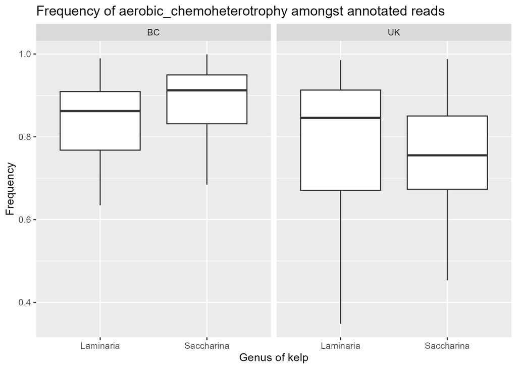

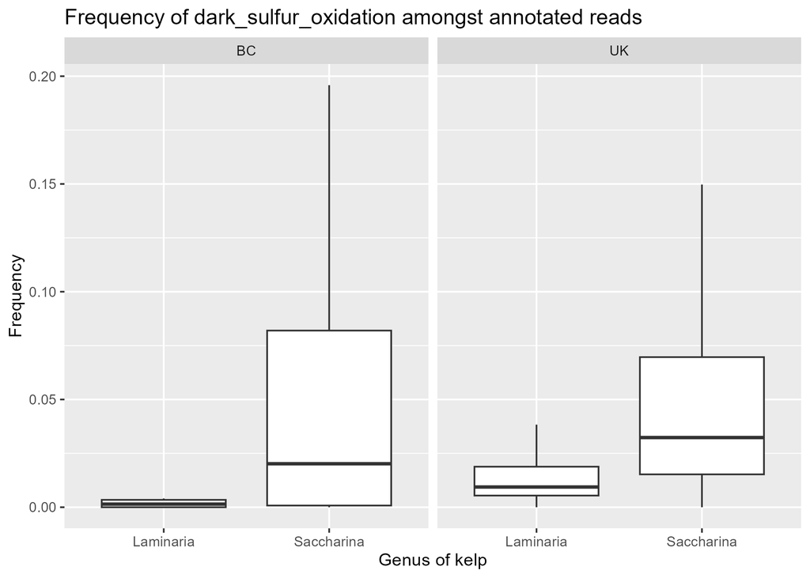

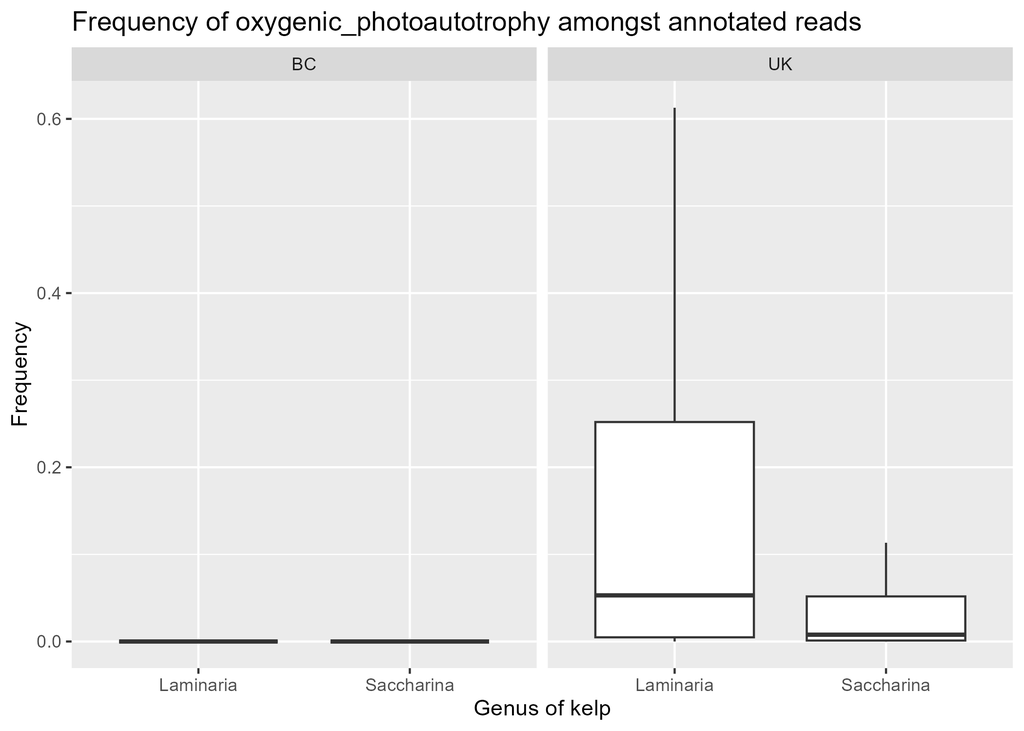

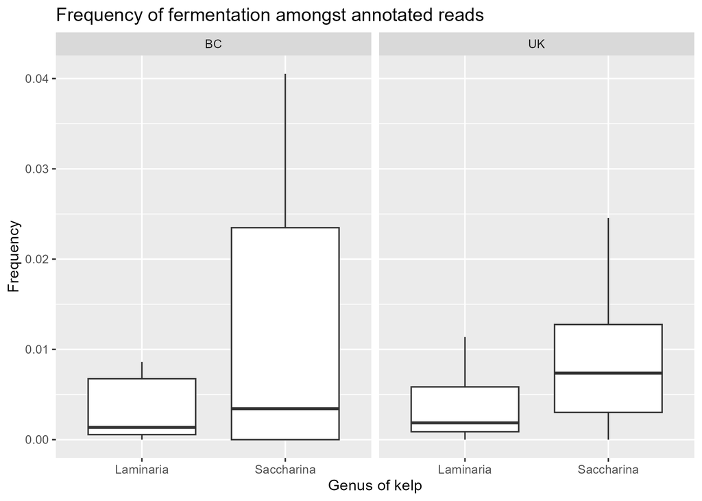

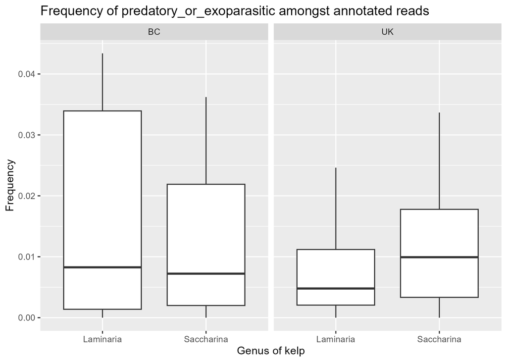

## Comparing for Statistical Significance

Now we must check to see if these differences have statistical significance. First, because there is a difference in the frequency with which FAPROTAX annotates taxa across both regions and species, and because this correlates with similar differences in the frequency that traits such as aerobic chemoheterotrophy are annotated, it is fair to assume that there is a bias in the overall frequency that traits are annotated within our samples. For this reason, we will proceed looking at only the frequency of different traits amongst annotated taxa, assuming that these taxa are representative of the overall community. Later we will attempt to verify this assumption

We will check if the difference between the frequency of different traits in our preliminary functional profile are different on *Saccharina* and *Laminaria* the UK and in BC.

```r
sig_vals = data.frame(matrix(ncol=6,nrow=0))
names(sig_vals) = c("Region", "eco_function", "p", "p.signif", "p.adj", "p.adj.signif")
main.funcs = list("aerobic_chemoheterotrophy", "dark_sulfur_oxidation", "oxygenic_photoautotrophy", "fermentation", "predatory_or_exoparasitic")
for(f in main.funcs){
  funcdata = subset(func_table.long, eco_function == f)
  sig.test = funcdata %>%
    group_by(Region) %>%
    t_test(relative_annotated_abundance ~ genus) %>%
    add_significance() %>%
    adjust_pvalue() %>%
    add_significance()
  sig.test = subset(sig.test, select = c("Region", "p", "p.signif", "p.adj", "p.adj.signif"))
  sig.test$eco_function = f
  sig_vals = rbind(sig_vals, sig.test)
}

print(sig_vals)
```

```
## # A tibble: 10 × 6
##    Region        p p.signif   p.adj p.adj.signif eco_function
##    <chr>     <dbl> <chr>      <dbl> <chr>        <chr>
##  1 BC     0.408    ns       0.788   ns           aerobic_chemoheterotrophy
##  2 UK     0.394    ns       0.788   ns           aerobic_chemoheterotrophy
##  3 BC     0.0399   *        0.0399  *            dark_sulfur_oxidation
##  4 UK     0.000949 ***      0.00190 **           dark_sulfur_oxidation
##  5 BC     0.577    ns       0.577   ns           oxygenic_photoautotrophy
##  6 UK     0.00737  **       0.0147  *            oxygenic_photoautotrophy
##  7 BC     0.0134   *        0.0268  *            fermentation
##  8 UK     0.419    ns       0.419   ns           fermentation
##  9 BC     0.482    ns       0.482   ns           predatory_or_exoparasitic
## 10 UK     0.0449   *        0.0898  ns           predatory_or_exoparasitic
```

Next we will see if the frequency of different traits in our preliminary functional profile are the same in the UK and in BC on *Saccharina* and *Laminaria*

```r
sig_vals = data.frame(matrix(ncol=6,nrow=0))
names(sig_vals) = c("genus", "eco_function", "p", "p.signif", "p.adj", "p.adj.signif")
for(f in main.funcs){
  funcdata = subset(func_table.long, eco_function == f)
  sig.test = funcdata %>%
    group_by(genus) %>%
    t_test(relative_annotated_abundance ~ Region) %>%
    add_significance() %>%
    adjust_pvalue() %>%
    add_significance()
  sig.test = subset(sig.test, select = c("genus", "p", "p.signif", "p.adj", "p.adj.signif"))
  sig.test$eco_function = f
  sig_vals = rbind(sig_vals, sig.test)
}

print(sig_vals)
```

```
## # A tibble: 10 × 6
##    genus               p p.signif      p.adj p.adj.signif eco_function
##    <chr>           <dbl> <chr>         <dbl> <chr>        <chr>
##  1 Laminaria  0.259      ns       0.259      ns           aerobic_chemoheterotr…
##  2 Saccharina 0.000007   ****     0.000014   ****         aerobic_chemoheterotr…
##  3 Laminaria  0.58       ns       1          ns           dark_sulfur_oxidation
##  4 Saccharina 0.983      ns       1          ns           dark_sulfur_oxidation
##  5 Laminaria  0.00000153 ****     0.00000306 ****         oxygenic_photoautotro…
##  6 Saccharina 0.00158    **       0.00158    **           oxygenic_photoautotro…
##  7 Laminaria  0.184      ns       0.368      ns           fermentation
##  8 Saccharina 0.834      ns       0.834      ns           fermentation
##  9 Laminaria  0.274      ns       0.548      ns           predatory_or_exoparas…
## 10 Saccharina 0.515      ns       0.548      ns           predatory_or_exoparas…
```

## OTUS expressing a given funcion

Next we will analyze the OTUs which were assigned each of our main functions

```r
ann_tab = read.table("kelpme_groups2records.txt", sep = "\t", row.names = 1, header = TRUE)

### Assemble phyloseqs by function ###
## aerobic chemoheterotrophy
a_chem = subset_taxa(kelp_me_clean, ann_tab$aerobic_chemoheterotrophy>0)

## dark sulfur oxidation
ds_ox = subset_taxa(kelp_me_clean, ann_tab$dark_sulfur_oxidation>0)
## must exclude data collected on Laminaria in BC as these were not significanty different from 0
ds_ox = subset_samples(ds_ox, genus == "Saccharina" | Region == "UK")

## fermentation
ferm = subset_taxa(kelp_me_clean, ann_tab$fermentation>0)
## must exclude data collected on Laminaria as these were not significanty different from 0
ferm = subset_samples(ferm, genus != "Laminaria")

## oxygenic photoautotrophy
o_pau = subset_taxa(kelp_me_clean, ann_tab$oxygenic_photoautotrophy>0)
## must exclude data collected in BC as these were not significanty different from 0
o_pau = subset_samples(o_pau, Region != "BC")

## predatory or exoparasitic
poe = subset_taxa(kelp_me_clean, ann_tab$predatory_or_exoparasitic>0)
```

Now we need to create our taxaplots.

```r
## load function
dephyloseq = function(phylo_obj){
  ## get the metadata
  meta = as.data.frame(as.matrix(phylo_obj@sam_data))
  ## how many metadata columns you have
  metacols = ncol(meta)+1
  ## get out the otu table
  ## if your metadta is empty after running this, you need to use
  otu = as.data.frame(t(as.matrix(phylo_obj@otu_table)))
  #otu = as.data.frame(as.matrix(phylo_obj@otu_table))
  ## merge the metadata and otu table by the rownames (sample ids from the Illumina sequencing   data)
  mo = merge(meta, otu, by=0)
  ## get out the taxonomy file
  tax = as.data.frame(phylo_obj@tax_table)
  ## get the ASV ID out. This the matches the placeholder ASV ID in the OTU table
  tax = tax %>% rownames_to_column(var="asv_id2")
  ## pivot longer to be able to match the ASVs in the OTU table to the taxonomy table
  mo = mo %>% pivot_longer(cols = -c(1:metacols), names_to = "asv_id2", values_to="asv_abundance")
  ## Join the metadata and otu table with the taoxnomy table
  mot = full_join(mo, tax)
  ## Specify the output for the dephyloseq funciton
  output = mot
}

a_chem = tax_glom(a_chem, taxrank = "species")
## calculate the number of reads in each sample. This is important for relative abundance calculations later
a_chem@sam_data$read_depth = sample_sums(a_chem)
## rename "genus" and "species" to specify that they refer to the kelp
names(a_chem@sam_data)[4] = "genus_kelp"
names(a_chem@sam_data)[5] = "species_kelp"
## remove samples where the function was not annotated
a_chem = subset_samples(a_chem, read_depth>0)
## remove samples taken from kelp other than Laminaria and Saccharina
a_chem = subset_samples(a_chem, genus_kelp == "Laminaria" | genus_kelp == "Saccharina")
## transform the phyloseq object into a data table, assigning the occurence of each OTU to the sample it was measured in
a_chem.df = dephyloseq(a_chem)
```

```r
## add the relative abundance of each taxa to our dataframe
a_chem.df$relative_abundance = as.numeric(a_chem.df$asv_abundance)/as.numeric(a_chem.df$read_depth)
## now add the names for each taxa and comparison group in our plots
a_chem.df$plot_names = paste0(a_chem.df$genus, ";", a_chem.df$species)
a_chem.df$comparison_names = paste0(a_chem.df$genus_kelp, ";", a_chem.df$Region)

ds_ox = tax_glom(ds_ox, taxrank = "species")
## calculate the number of reads in each sample. This is important for relative abundance calculations later
ds_ox@sam_data$read_depth = sample_sums(ds_ox)
## rename "genus" and "species" to specify that they refer to the kelp
names(ds_ox@sam_data)[4] = "genus_kelp"
names(ds_ox@sam_data)[5] = "species_kelp"
## remove samples where the function was not annotated
ds_ox = subset_samples(ds_ox, read_depth>0)
## remove samples taken from kelp other than Laminaria and Saccharina
ds_ox = subset_samples(ds_ox, genus_kelp == "Laminaria" | genus_kelp == "Saccharina")
## transform the phyloseq object into a data table, assigning the occurence of each OTU to the sample it was measured in
ds_ox.df = dephyloseq(ds_ox)
## add the relative abundance of each taxa to our dataframe
ds_ox.df$relative_abundance = as.numeric(ds_ox.df$asv_abundance)/as.numeric(ds_ox.df$read_depth)
## now add the names for each taxa and comparison group in our plots
ds_ox.df$plot_names = paste0(ds_ox.df$genus, ";", ds_ox.df$species)
ds_ox.df$comparison_names = paste0(ds_ox.df$genus_kelp, ";", ds_ox.df$Region)


ferm = tax_glom(ferm, taxrank = "species")
## calculate the number of reads in each sample. This is important for relative abundance calculations later
ferm@sam_data$read_depth = sample_sums(ferm)
## rename "genus" and "species" to specify that they refer to the kelp
names(ferm@sam_data)[4] = "genus_kelp"
names(ferm@sam_data)[5] = "species_kelp"
## remove samples where the function was not annotated
ferm = subset_samples(ferm, read_depth>0)
## remove samples taken from kelp other than Laminaria and Saccharina
ferm = subset_samples(ferm, genus_kelp == "Laminaria" | genus_kelp == "Saccharina")
## transform the phyloseq object into a data table, assigning the occurence of each OTU to the sample it was measured in
ferm.df = dephyloseq(ferm)
## add the relative abundance of each taxa to our dataframe
ferm.df$relative_abundance = as.numeric(ferm.df$asv_abundance)/as.numeric(ferm.df$read_depth)
## now add the names for each taxa and comparison group in our plots
ferm.df$plot_names = paste0(ferm.df$genus, ";", ferm.df$species)
ferm.df$comparison_names = paste0(ferm.df$genus_kelp, ";", ferm.df$Region)


o_pau = tax_glom(o_pau, taxrank = "species")
## calculate the number of reads in each sample. This is important for relative abundance calculations later
o_pau@sam_data$read_depth = sample_sums(o_pau)
## rename "genus" and "species" to specify that they refer to the kelp
names(o_pau@sam_data)[4] = "genus_kelp"
names(o_pau@sam_data)[5] = "species_kelp"
## remove samples where the function was not annotated
o_pau = subset_samples(o_pau, read_depth>0)
## remove samples taken from kelp other than Laminaria and Saccharina
o_pau = subset_samples(o_pau, genus_kelp == "Laminaria" | genus_kelp == "Saccharina")
## transform the phyloseq object into a data table, assigning the occurence of each OTU to the sample it was measured in
o_pau.df = dephyloseq(o_pau)
## add the relative abundance of each taxa to our dataframe
o_pau.df$relative_abundance = as.numeric(o_pau.df$asv_abundance)/as.numeric(o_pau.df$read_depth)
## now add the names for each taxa and comparison group in our plots
o_pau.df$plot_names = paste0(o_pau.df$genus, ";", o_pau.df$species)
o_pau.df$comparison_names = paste0(o_pau.df$genus_kelp, ";", o_pau.df$Region)


poe = tax_glom(poe, taxrank = "species")
## calculate the number of reads in each sample. This is important for relative abundance calculations later
poe@sam_data$read_depth = sample_sums(poe)
## rename "genus" and "species" to specify that they refer to the kelp
names(poe@sam_data)[4] = "genus_kelp"
names(poe@sam_data)[5] = "species_kelp"
## remove samples where the function was not annotated
poe = subset_samples(poe, read_depth>0)
## remove samples taken from kelp other than Laminaria and Saccharina
poe = subset_samples(poe, genus_kelp == "Laminaria" | genus_kelp == "Saccharina")
## transform the phyloseq object into a data table, assigning the occurence of each OTU to the sample it was measured in
poe.df = dephyloseq(poe)
## add the relative abundance of each taxa to our dataframe
poe.df$relative_abundance = as.numeric(poe.df$asv_abundance)/as.numeric(poe.df$read_depth)
## now add the names for each taxa and comparison group in our plots
poe.df$plot_names = paste0(poe.df$genus, ";", poe.df$species)
poe.df$comparison_names = paste0(poe.df$genus_kelp, ";", poe.df$Region)
```

Before proceeding we can now check if these functions are expressed by a single genus, or by many genuses.

```r
## aerobic chemoheterotrophy
print(length(unique(a_chem.df$plot_names)))
```

```
## [1] 141
```

```r
print(head(unique(a_chem.df$plot_names)))
```

```
## [1] "Blastopirellula;Blastopirellula" "Maribacter;Maribacter"
## [3] "Polaribacter;Polaribacter"       "Rubritalea;Rubritalea"
## [5] "Leucothrix;Leucothrix"           "Sulfitobacter;Sulfitobacter"
```

```r
## dark sulfur oxidation
print(length(unique(ds_ox.df$plot_names)))
```

```
## [1] 6
```

```r
print(head(unique(ds_ox.df$plot_names)))
```

```
## [1] "Sulfitobacter;Sulfitobacter" "Sulfitobacter;brevis"
## [3] "Sulfitobacter;litoralis"     "Sulfitobacter;undariae"
## [5] "Sulfitobacter;noctilucae"    "Sulfitobacter;dubius"
```

```r
## fermentation
print(length(unique(ferm.df$plot_names)))
```

```
## [1] 26
```

```r
print(head(unique(ferm.df$plot_names)))
```

```
## [1] "Colwellia;Colwellia"       "Truepera;Truepera"
## [3] "Colwellia;mytili"          "Aliivibrio;Aliivibrio"
## [5] "Algibacter;Algibacter"     "Colwellia;psychrerythraea"
```

```r
## oxygenic photoautotrophy
print(length(unique(o_pau.df$plot_names)))
```

```
## [1] 13
```

```r
print(head(unique(o_pau.df$plot_names)))
```

```
## [1] "Chroococcidiopsis_PCC-6712;Chroococcidiopsis_PCC-6712"
## [2] "Cyanobacteriia;Cyanobacteriia"
## [3] "Pleurocapsa_PCC-7319;Pleurocapsa_PCC-7319"
## [4] "Synechococcus_CC9902;Synechococcus_CC9902"
## [5] "Acaryochloris_MBIC11017;Acaryochloris_MBIC11017"
## [6] "Pseudanabaena_NgrPSln22;Pseudanabaena_NgrPSln22"
```

```r
## predatory or exoparasitic
print(length(unique(poe.df$plot_names)))
```

```
## [1] 3
```

```r
print(head(unique(poe.df$plot_names)))
```

```
## [1] "OM27_clade;OM27_clade"     "Bdellovibrio;Bdellovibrio"
## [3] "Haliangium;Haliangium"
```

To analyze these functions we will first summarize their relative abundance data.

```r
### aerobic chemoheterotrophy ###
## summarize the data
a_chem.sum = ddply(a_chem.df, c("plot_names"), summarise, sum = sum(relative_abundance))
## sort by relative abundance
a_chem.sorted = a_chem.sum[order(-a_chem.sum$sum),]
# take the top 15 genera
a_chem.top = a_chem.sorted[c(1:15),]
a_chem.top$place = "top_15"
## recombine with the rest of our data
a_chem.all = full_join(a_chem.df, a_chem.top)
## make the empty "place" cells say bottom. This works because we used full_join
a_chem.all$place = replace(a_chem.all$place, is.na(a_chem.all$place), "bottom")
## replace plot_names that have bottom taxa as their "place" with Other
a_chem.all[a_chem.all$place == "bottom",]$plot_names = "Others"
## order by decreasing relative abundance
a_chem.all = a_chem.all[order(-a_chem.all$relative_abundance),]
## get list of factors in order
natural.genus.order = as.list(c(unique(a_chem.all$plot_names)))
## remove others from list #!#
no.others=natural.genus.order[!natural.genus.order == 'Others']
## add Others to end of list
plot.order = append(no.others, "Others")
## set plot_names levels
plot.order = unlist(plot.order)
## order dataframe by relative abundance
a_chem.all$plot_names = factor(a_chem.all$plot_names, levels=c(plot.order))

### fermentation ###
## summarize the data
ferm.sum = ddply(ferm.df, c("plot_names"), summarise, sum = sum(relative_abundance))
## sort by relative abundance
ferm.sorted = ferm.sum[order(-ferm.sum$sum),]
# take the top 5 genera
ferm.top = ferm.sorted[c(1:10),]
ferm.top$place = "top_10"
## recombine with the rest of our data
ferm.all = full_join(ferm.df, ferm.top)
## make the empty "place" cells say bottom. This works because we used full_join
ferm.all$place = replace(ferm.all$place, is.na(ferm.all$place), "bottom")
## replace plot_names that have bottom taxa as their "place" with Other
ferm.all[ferm.all$place == "bottom",]$plot_names = "Others"
## order by decreasing relative abundance
ferm.all = ferm.all[order(-ferm.all$relative_abundance),]
## get list of factors in order
natural.genus.order = as.list(c(unique(ferm.all$plot_names)))
## remove others from list #!#
no.others=natural.genus.order[!natural.genus.order == 'Others']
## add Others to end of list
plot.order = append(no.others, "Others")
## set plot_names levels
plot.order = unlist(plot.order)
## order dataframe by relative abundance
ferm.all$plot_names = factor(ferm.all$plot_names, levels=c(plot.order))

### oxygenic photoautotrophy ###
## summarize the data
o_pau.sum = ddply(o_pau.df, c("plot_names"), summarise, sum = sum(relative_abundance))
## sort by relative abundance
o_pau.sorted = o_pau.sum[order(-o_pau.sum$sum),]
# take the top 5 genera
o_pau.top = o_pau.sorted[c(1:10),]
o_pau.top$place = "top_10"
## recombine with the rest of our data
o_pau.all = full_join(o_pau.df, o_pau.top)
## make the empty "place" cells say bottom. This works because we used full_join
o_pau.all$place = replace(o_pau.all$place, is.na(o_pau.all$place), "bottom")
## replace plot_names that have bottom taxa as their "place" with Other
o_pau.all[o_pau.all$place == "bottom",]$plot_names = "Others"
## order by decreasing relative abundance
o_pau.all = o_pau.all[order(-o_pau.all$relative_abundance),]
## get list of factors in order
natural.genus.order = as.list(c(unique(o_pau.all$plot_names)))
## remove others from list #!#
no.others=natural.genus.order[!natural.genus.order == 'Others']
## add Others to end of list
plot.order = append(no.others, "Others")
## set plot_names levels
plot.order = unlist(plot.order)
## order dataframe by relative abundance
o_pau.all$plot_names = factor(o_pau.all$plot_names, levels=c(plot.order))

### predaorty or exoparaisitic ###
## summarize the data
poe.sum = ddply(poe.df, c("plot_names"), summarise, sum = sum(relative_abundance))
## sort by relative abundance
poe.sorted = poe.sum[order(-poe.sum$sum),]
## order by decreasing relative abundance
poe.df = poe.df[order(-poe.df$relative_abundance),]
## get list of factors in order
natural.genus.order = as.list(c(unique(poe.df$plot_names)))
## remove others from list #!#
no.others=natural.genus.order[!natural.genus.order == 'Others']
## add Others to end of list
plot.order = append(no.others, "Others")
## set plot_names levels
plot.order = unlist(plot.order)
## order dataframe by relative abundance
poe.df$plot_names = factor(poe.df$plot_names, levels=c(plot.order))

### dark sulfur oxidation ###
## summarize the data
ds_ox.sum = ddply(ds_ox.df, c("plot_names"), summarise, sum = sum(relative_abundance))
## sort by relative abundance
ds_ox.sorted = ds_ox.sum[order(-ds_ox.sum$sum),]
## order by decreasing relative abundance
ds_ox.df = ds_ox.df[order(-ds_ox.df$relative_abundance),]
## get list of factors in order
natural.genus.order = as.list(c(unique(ds_ox.df$plot_names)))
## remove others from list #!#
no.others=natural.genus.order[!natural.genus.order == 'Others']
## add Others to end of list
plot.order = append(no.others, "Others")
## set plot_names levels
plot.order = unlist(plot.order)
## order dataframe by relative abundance
ds_ox.df$plot_names = factor(ds_ox.df$plot_names, levels=c(plot.order))
```

```r
## aerobic chemoheterotrophy
a_chem.plot = ggplot(a_chem.all, aes(x=as.character(Row.names), y=as.numeric(relative_abundance), fill=as.factor(plot_names)))+
  geom_bar(stat = "identity")+
  guides(fill=guide_legend(ncol=2))+
  facet_grid(.~comparison_names, scales="free", space="free")+
  theme_bw()+
  theme(panel.grid = element_blank(),strip.background = element_rect(fill="white"),
        axis.text.y = element_text(size = 10, colour = "black"),
        axis.title = element_text(size=10,face="bold"),
        strip.text = element_text(color="black", size=10),
        legend.text=element_text(size=6),
        axis.line = element_line(colour = "black"),
        axis.text.x = element_blank())+
  labs(y="Relative Abundance", x="Sample", fill="Taxa")+
  ggtitle("Taxa assigned trait aerobic chemoheterotrophy")


ggsave("Taxa assigned trait aerobic chemoheterotrophy.png", plot = a_chem.plot, path = "figures/taxaplots", width = 20, height = 10)

## fermentation
ferm.plot = ggplot(ferm.all, aes(x=as.character(Row.names), y=as.numeric(relative_abundance), fill=as.factor(plot_names)))+
  geom_bar(stat = "identity")+
  guides(fill=guide_legend(ncol=2))+
  facet_grid(.~comparison_names, scales="free", space="free")+
  theme_bw()+
  theme(panel.grid = element_blank(),strip.background = element_rect(fill="white"),
        axis.text.y = element_text(size = 10, colour = "black"),
        axis.title = element_text(size=10,face="bold"),
        strip.text = element_text(color="black", size=10),
        legend.text=element_text(size=6),
        axis.line = element_line(colour = "black"),
        axis.text.x = element_blank())+
  labs(y="Relative Abundance", x="Sample", fill="Taxa")+
  ggtitle("Taxa assigned trait fermentation")


ggsave("Taxa assigned trait fermentation.png", plot = ferm.plot, path = "figures/taxaplots", width = 20, height = 10)

## oxygenic photoautotrophy
o_pau.plot = ggplot(o_pau.all, aes(x=as.character(Row.names), y=as.numeric(relative_abundance), fill=as.factor(plot_names)))+
  geom_bar(stat = "identity")+
  guides(fill=guide_legend(ncol=2))+
  facet_grid(.~comparison_names, scales="free", space="free")+
  theme_bw()+
  theme(panel.grid = element_blank(),strip.background = element_rect(fill="white"),
        axis.text.y = element_text(size = 10, colour = "black"),
        axis.title = element_text(size=10,face="bold"),
        strip.text = element_text(color="black", size=10),
        legend.text=element_text(size=6),
        axis.line = element_line(colour = "black"),
        axis.text.x = element_blank())+
  labs(y="Relative Abundance", x="Sample", fill="Taxa")+
  ggtitle("Taxa assigned trait oxygenic photoautotrophy")


ggsave("Taxa assigned trait oxygenic photoautotrophy.png", plot = o_pau.plot, path = "figures/taxaplots", width = 20, height = 10)

## predatory or exoparasitic
poe.plot = ggplot(poe.df, aes(x=as.character(Row.names), y=as.numeric(relative_abundance), fill=as.factor(plot_names)))+
  geom_bar(stat = "identity")+
  guides(fill=guide_legend(ncol=2))+
  facet_grid(.~comparison_names, scales="free", space="free")+
  theme_bw()+
  theme(panel.grid = element_blank(),strip.background = element_rect(fill="white"),
        axis.text.y = element_text(size = 10, colour = "black"),
        axis.title = element_text(size=10,face="bold"),
        strip.text = element_text(color="black", size=10),
        legend.text=element_text(size=6),
        axis.line = element_line(colour = "black"),
        axis.text.x = element_blank())+
  labs(y="Relative Abundance", x="Sample", fill="Taxa")+
  ggtitle("Taxa assigned trait predatory or exoparasitic")

ggsave("Taxa assigned trait predatory or exoparasitic.png", plot = poe.plot, path = "figures/taxaplots", width = 20, height = 10)

## dark sulfur oxidation
ds_ox.plot = ggplot(ds_ox.df, aes(x=as.character(Row.names), y=as.numeric(relative_abundance), fill=as.factor(plot_names)))+
  geom_bar(stat = "identity")+
  guides(fill=guide_legend(ncol=2))+
  facet_grid(.~comparison_names, scales="free", space="free")+
  theme_bw()+
  theme(panel.grid = element_blank(),strip.background = element_rect(fill="white"),
        axis.text.y = element_text(size = 10, colour = "black"),
        axis.title = element_text(size=10,face="bold"),
        strip.text = element_text(color="black", size=10),
        legend.text=element_text(size=6),
        axis.line = element_line(colour = "black"),
        axis.text.x = element_blank())+
  labs(y="Relative Abundance", x="Sample", fill="Taxa")+
  ggtitle("Taxa assigned trait dark sulfur oxidation")

ggsave("Taxa assigned trait dark sulfur oxidation.png", plot = ds_ox.plot, path = "figures/taxaplots", width = 20, height = 10)
```

This gives the relevant taxa plots:

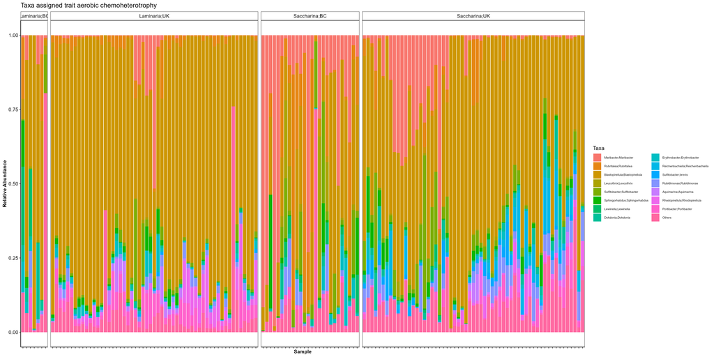

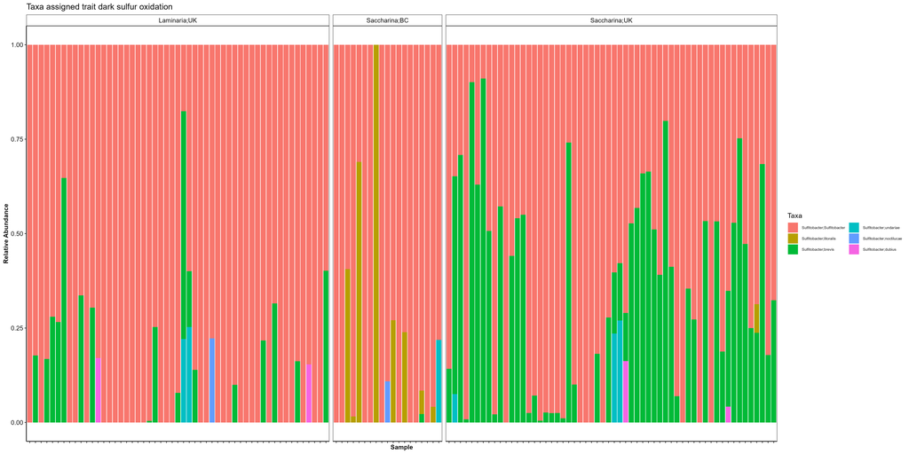

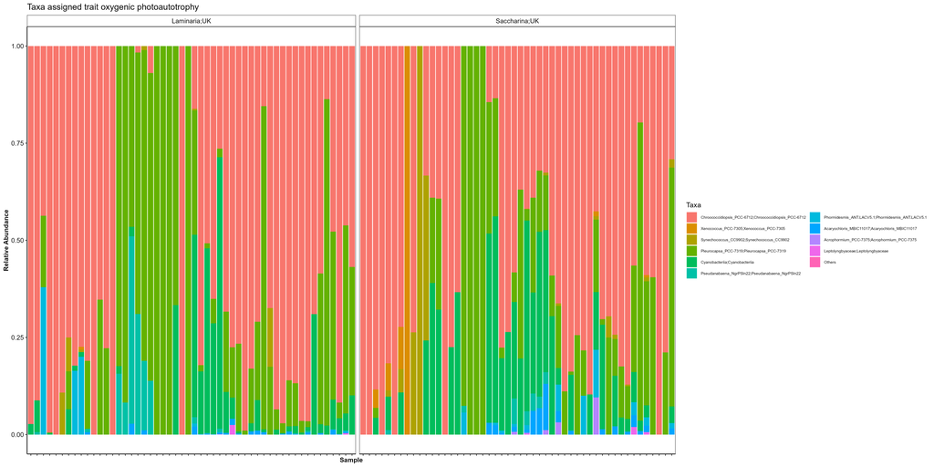

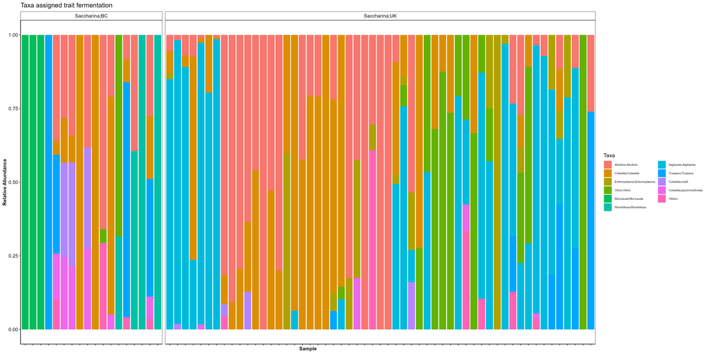

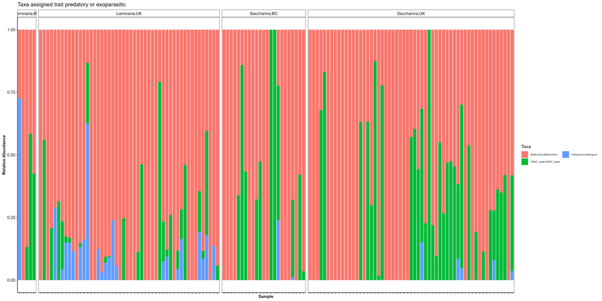